# Fantasy Footbal Model

Jacob Cohn

12/10/2021

### Introduction

Millions of people compete against their friends in fantasy sports every year. In fantasy football, a group of about twelve people will take turns selecting professional football players to add to their roster. They then use those rosters to compete against each other by seeing whose roster scores more fantasy points over the course of a week.

#### Objective Statement

The purpose of this project is to generate a model that will help predict fantasy point production of players given their age and their position. To get enough data to run a sufficient model, every play from every NFL game since 2001 is being included. A majority of this project is focused on cleaning and managing the data to easily run the model. This is because future projects will rely heavily on the data being created from this project. The following report will be broken into Data Cleaning, Fantasy Point Calculation, and Analysis.

### Data Cleaning

#### Gather PBP Data

The first step in this project is to gather the records of every football play that has happened over the time period we are interested in, which can be acquired through nflfastR. This code will write every play into a csv, however the playoff games have been removed since they will bias our analysis. There are hundreds of columns that will need to be parsed but the first few rows of the description column has been displayed to show that we will be dealing with different play types, players, and yardage amounts.

```r
source("src/gather_pbp.R")
head(data$desc,n=5)
```

```
## [1] "GAME"
## [2] "7-B.Gramatica kicks 59 yards from ARI 30 to WAS 11. 32-K.Watson to WAS 33 for 22 yards (44-M.Stone)."
## [3] "(14:54) 48-S.Davis right tackle to WAS 34 for 1 yard (94-M.Bell)."
## [4] "(14:15) 6-S.Matthews pass to 48-S.Davis to WAS 41 for 7 yards (98-R.Davis)."
## [5] "(13:44) 48-S.Davis right tackle to WAS 45 for 4 yards (94-M.Bell)."
```

```r
rm(list=ls())
```

#### Gathering Rosters

```r
source("src/gather_roster.R")
head(rosters[,7:12],n=5)
```

| full_name | first_name | last_name | birth_date | height | weight |
| --- | --- | --- | --- | --- | --- |
| Steven Grace | Steven | Grace | 1979-02-13 | 6-3 | 296 |
| Jason Starkey | Jason | Starkey | 1977-07-15 | 6-4 | 297 |
| Nathan Hodel | Nathan | Hodel | 1977-11-12 | 6-2 | 245 |
| Mike Gruttadauria | Mike | Gruttadauria | 1972-12-06 | 6-3 | 280 |
| David Barrett | David | Barrett | 1977-12-22 | 5-10 | 198 |

```r
rm(list=ls())
```

#### Aggreagting PBP Data

```r
summary_stats<-read.csv("data/summary_statistics.csv")
head(summary_stats[,2:5],n=5)
```

|  | PlayerID | week | season | Assist |
| --- | --- | --- | --- | --- |
| 1 | 00-0000007 | 3 | 2002 | 1 |
| 2 | 00-0000007 | 7 | 2004 | 1 |
| 3 | 00-0000007 | 9 | 2003 | 2 |
| 4 | 00-0000007 | 11 | 2003 | 1 |
| 5 | 00-0000007 | 12 | 2003 | 1 |

```r
rm(list=ls())
```

#### Combining Roster Data and Summary Statistics

To get the names of the players whose stats are given in the table above, we need to merge the stats with the roster by PlayerID. This code looks up the PlayerID’s and adds the appropriate name, team, height, weight, etc. It also calculates each player’s age based on their birthday and what the year was in the season they were playing.

```r
source("src/combine_stats_and_roster.R")
head(filled_stats[,c(1,2,3,4,5,9,63)],n=5)
```

|  | PlayerID | season | position | team | full_name | week | Tackle |
| --- | --- | --- | --- | --- | --- | --- | --- |
| 1 | 00-0000007 | 2002 | RB | CHI | Rabih Abdullah | 13 | 1 |
| 2 | 00-0000007 | 2002 | RB | CHI | Rabih Abdullah | 10 | 2 |
| 3 | 00-0000007 | 2002 | RB | CHI | Rabih Abdullah | 3 | 1 |
| 4 | 00-0000007 | 2002 | RB | CHI | Rabih Abdullah | 11 | 1 |
| 5 | 00-0000007 | 2002 | RB | CHI | Rabih Abdullah | 5 | NA |

```r
rm(list=ls())
```

### Calculating Fantasy Points

Now that we have the data in a neat and understandable format, it’s time to calculate how many fantasy points each player scored. This section of code is dependent on two files. The first is the weekly_fantasy_points.csv file that we created in the data folder during the last function. The second is the points.csv which says how many fantasy points each play is worth. This function will multiply each players stats by how much that stat is worth. All those values are then summed up into the FPoints column to denote how many Fantasy Points the player scored that week. Below is a subset of the data to show what Fantasy Points production looks like in a given week.

```r
source("src/calculate_Fantasy_Points.R")
head(weekly_sums_df[,c(2,3,4,5,6,10,66)],n=5)
```

|  | PlayerID | season | position | team | full_name | week | FPoints |
| --- | --- | --- | --- | --- | --- | --- | --- |
| 1 | 00-0000007 | 2002 | RB | CHI | Rabih Abdullah | 13 | 1.75 |
| 2 | 00-0000007 | 2002 | RB | CHI | Rabih Abdullah | 10 | 1.00 |
| 3 | 00-0000007 | 2002 | RB | CHI | Rabih Abdullah | 3 | 1.57 |
| 4 | 00-0000007 | 2002 | RB | CHI | Rabih Abdullah | 11 | 0.50 |
| 5 | 00-0000007 | 2002 | RB | CHI | Rabih Abdullah | 5 | -2.00 |

```r
rm(list=ls())
```

#### Analysis

We finish by testing to see what effects age and position you play have on your fantasy point production. So, we will load in the weekly fantasy point statistics that we generated in the last function and sum up their production for the full year.

```r
season_df <- fantasy_df%>%
  dplyr::group_by(PlayerID,season, position,team,full_name,age)%>%
   dplyr::summarise_at(sum_cols, sum, na.rm=TRUE) %>%
  dplyr::ungroup()
```

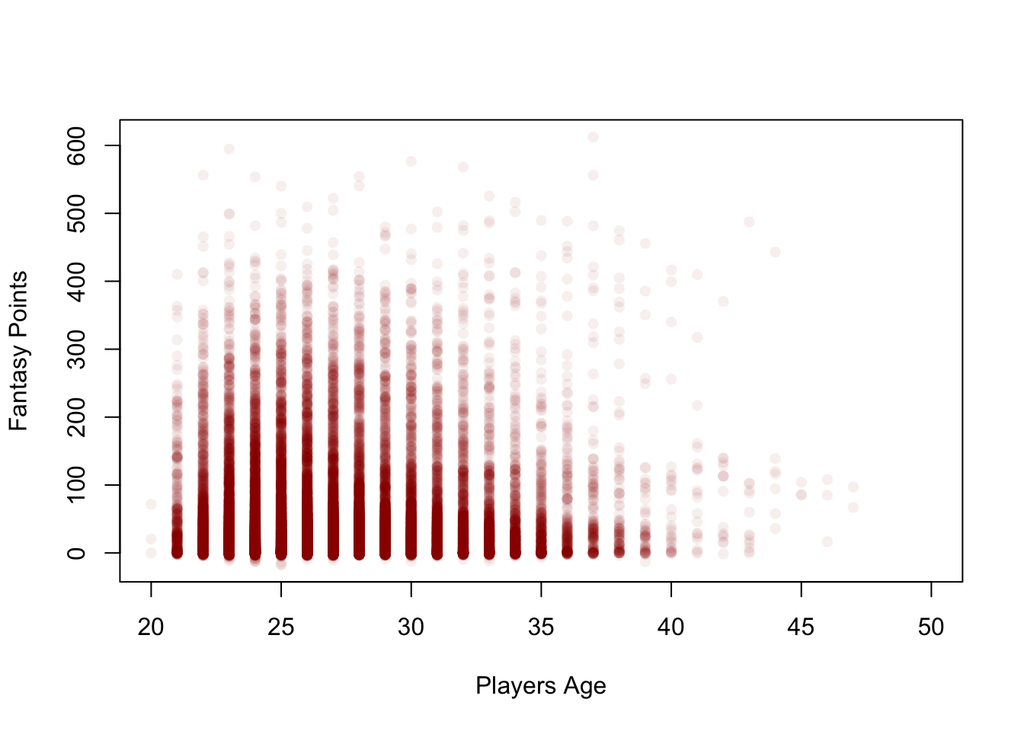

```r
plot(season_df$age,season_df$FPoints,xlab = 'Players Age',ylab = 'Fantasy Points',xlim = c(20,50),col=rgb(.6,0,0,0.065),pch=16)
```

We are going to create and age^2 value for each player since there seems to a be a parabolic relationship between age and fantasy points.

```r
season_df$age2 <- season_df$age^2
```

Here we are running a fixed effects model on the data to see what the coefficients of age and age^2 are. We are using a fixed effects model because we want each player to have their own intercept. This allows us to make predictions about individual players point production. We include age^2 because the graph of the relationship between age and fantasy points shows a downward facing parabola.

```r
fixed.dum <- lm(formula = FPoints ~ age + age2 +factor(position) + factor(PlayerID),data = season_df)
```

```r
summary(fixed.dum)
```

```
##
## Call:
## lm(formula = FPoints ~ age + age2 + factor(position) + factor(PlayerID),
##     data = season_df)
##
## Residuals:
##     Min      1Q  Median      3Q     Max
## -409.05   -7.10    0.00    6.72  307.40
##
## Coefficients: (1 not defined because of singularities)
##                              Estimate Std. Error t value Pr(>|t|)
## (Intercept)                -136.45741   26.09238  -5.230 1.71e-07 ***
## age                          13.07644    0.88553  14.767  < 2e-16 ***
## age2                         -0.26811    0.01578 -16.991  < 2e-16 ***
## factor(position)CB          -13.24599   10.80915  -1.225 0.220419
## factor(position)DB          -21.83158   10.70213  -2.040 0.041367 *
## factor(position)DE           -4.10133    9.18591  -0.446 0.655254
## factor(position)DL          -18.57153   28.83892  -0.644 0.519597
## factor(position)DT           -5.23571    9.28361  -0.564 0.572777
## factor(position)FB            6.72215    9.53854   0.705 0.480981
## factor(position)FS           -8.17493   10.82763  -0.755 0.450252
## factor(position)G            -2.47247    3.06544  -0.807 0.419924
## factor(position)HB           18.48449   20.57726   0.898 0.369035
## factor(position)ILB           8.79880    9.37486   0.939 0.347969
## factor(position)K            74.54290   42.54683   1.752 0.079781 .
## factor(position)LB           -7.82452    9.12502  -0.857 0.391188
## factor(position)LS           13.14408    7.17937   1.831 0.067140 .
## factor(position)MLB          10.62942    9.45096   1.125 0.260729
## factor(position)NT           -2.26566    9.58223  -0.236 0.813090
## factor(position)OG           -0.31844    3.60207  -0.088 0.929555
## factor(position)OL            3.36076    5.84670   0.575 0.565422
## factor(position)OLB           3.74375    9.18664   0.408 0.683628
## factor(position)OT           -1.61809    4.17182  -0.388 0.698121
## factor(position)P            69.56059   56.91503   1.222 0.221649
## factor(position)QB          -50.76355   19.98309  -2.540 0.011080 *
## factor(position)RB            0.06883    9.69859   0.007 0.994337
## factor(position)SAF         -24.25467   12.32658  -1.968 0.049116 *
## factor(position)SS           -6.52314   10.78265  -0.605 0.545206
## factor(position)T            -3.42819    3.81263  -0.899 0.368571
## factor(position)TE            1.58485    8.54824   0.185 0.852917
```

[output cut: 16 more lines]

```
## factor(PlayerID)00-0000251   75.94334   26.45788   2.870 0.004103 **
## factor(PlayerID)00-0000261   51.22569   30.55505   1.677 0.093651 .
## factor(PlayerID)00-0000282  109.24190   39.52448   2.764 0.005715 **
## factor(PlayerID)00-0000313  102.46507   41.61446   2.462 0.013813 *
## factor(PlayerID)00-0000339  104.34159   29.52378   3.534 0.000410 ***
## factor(PlayerID)00-0000352  -10.13403   26.65039  -0.380 0.703757
## factor(PlayerID)00-0000374  -14.93483   27.95845  -0.534 0.593222
## factor(PlayerID)00-0000400  -62.49434   57.96524  -1.078 0.280983
## ---
## Signif. codes:  0 '***' 0.001 '**' 0.01 '*' 0.05 '.' 0.1 ' ' 1
##
## Residual standard error: 35.87 on 27572 degrees of freedom
##   (1095 observations deleted due to missingness)
## Multiple R-squared:  0.7588, Adjusted R-squared:  0.6815
## F-statistic: 9.825 on 8827 and 27572 DF,  p-value: < 2.2e-16
```

With these regression results we have a way to make predictions about players fantasy point production given their previous years performance and what their age will be in the next season. We see statistically significant coefficients at the 0.001 level for both age and age^2. The negative coefficient on age^2 confirms our earlier hypothesis that age had a downard facing second degree polynomial relationship with fantasy point production.

#### Where To Go From Here

The results of this project have laid the foundation for much larger and more intense fantasy football projects. Being able to change how fantasy points are calculated using the calculate_Fantasy_Points.R script allows others to adapt this model for their own fantasy leagues which use their own rule set. The next steps necessary in fantasy football analysis is comparing players against each other and deciding how much more valuable one is than another. After that is completed a linear program can be run that will produce optimal fantasy rosters.